Prototype · 2026-10-16 · Fable

# Vintage Art Kit — where it lives on the toolbar

*◆* Event Hub Pro — tried free, named "Decorations" at ✓ Apply*✓* one dropdown per set of choices*✓* four rows, 44-px controls*✓* piece + spot + scene (rd/vintage-art-kit's shape)*✓* light · dark

Page theme

## A · The whole page — Studio › Look › Elements › **Accents ◆**

Where the look itself is picked. The art-kit builder (rd/vintage-art-kit) already put a **Decorations On/Off switch** under Elements; this turns that one row into the house dropdown — **Accents ◆ ▾ · None · Vintage** — whose choices are pictures, and lays the set's eight pieces under it as cards. One tap on Vintage = the whole set placed in its fixed spots (drapes + araña on the cover, posts at the countdown, spray + fan on e-gifts, garland over Reply, seal on the veil, oval at the closing). Tap a piece card to leave that piece out everywhere. Same column (`events.site_decorations`), one more value later when a second kit ships.

### Before — the Maker today

✕

Invitation ▾Studio ▾

↶✓

Studio · **Look**

Look ▾

BackgroundElementsMusic

Colours ▾

Font Cormorant ▾

Buttons Pill ▾

Decorations ◆ Event Hub Pro

Drawn from the code, not captured (no dev server tonight — the account's weekly budget; the lab's WALK lane was held by two builders): Studio › Look › Elements as rd/vintage-art-kit builds it — Colours · Font · Buttons, then the builder's **Decorations** On/Off switch (`StudioDecorations`, `studio-tools.tsx`).

### After — Studio › Look · Elements

✕

Invitation ▾Studio ▾

↶✓**1**

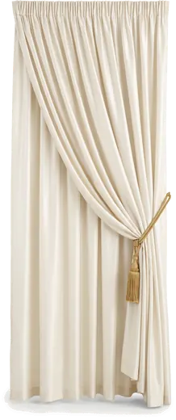

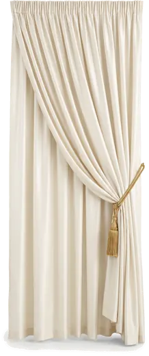

[figure not shown]

Studio · **Look**

BackgroundElementsMusic

Colours ▾

Buttons Pill ▾

Accents · comes with the Vintage look

**Tap Accents ◆ ▾** → None · Vintage, each with its picture. Vintage on: the cover above wears the drapes and the araña at once; the eight pieces sit under it as cards — tap one to leave it out of the whole Event Hub. ◆ = tried free here, named **Decorations** at ✓ Apply.

At ✓ ApplyTheme · Vintage, with its **Decorations**◆ Event Hub Pro

## B · One scene — tap the countdown, then **Style** › Accents row

The Style toolbar exactly as you see it (your TITLE › Style screenshot, left): rows 1–3 the style cards, row 4 Colour · Size. On a **scene**, the cards take rows 1–2 (the Dress code's palette row already does this) and **row 3 becomes Accents**: the pieces on this scene as small cards — ✓ on, tap to remove — and **＋ Add**, which opens a sheet of the set's eight pieces. A piece snaps to a fixed spot; while one is picked, **Spot ▾** (Top · Left · Right · Corners) is the one dropdown. No drag, no free placement.

### Before — your Style toolbar today

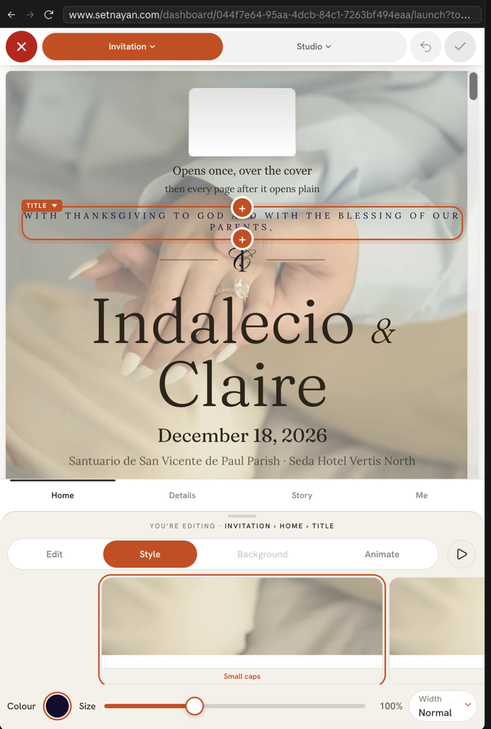

Your screenshot, untouched: Invitation › Home › **TITLE** › Style. Cards in rows 1–3, Colour · Size · Width in row 4.

### After — Countdown › Style

✕

Invitation ▾Studio ▾

↶✓**2**

Countdown +

HomeDetailsStoryMe

You're editing · **Invitation › Home › Countdown**

EditStyleBackgroundAnimate

▷

ColourSize100%

Add to the countdown · the Vintage set

A piece snaps to a spot on this scene. Change where with Spot ▾.

Spot

**Row 3 is new.** The two narra posts are on this scene (✓). Tap one to take it off; tap it again to put it back. **＋ Add** opens the set; pick the garland and it snaps to **Top**; tap its card and **Spot ▾** appears to move it. The canvas above answers every tap.

#### Style › Accents row — or accents as parts under the page's ＋?

Recommended · Style › Accents row (B) + Look › Accents ◆ (A)

- One tap for the whole set in Look; per-scene pruning in Style, where the scene's look already lives.
- Nothing new to learn: a dropdown, cards, ✓ — the shapes already on this toolbar.
- A piece can never be mis-placed: Spot ▾ is four named boxes, written as piece + slot + scene.
- FREE sees the row with ◆; PRO changes it. Off is always free.

Alternative · accents as parts via ＋ (my earlier idea)

- Each piece becomes a part in the page's ＋ sheet, with its own Edit/Style/Animate.
- More places to tap: eight parts × four tabs, and a part needs a position — a drag, or a Spot dropdown anyway.
- The set loses its one switch: "Vintage on" would be eight adds; Apply names eight lines.
- Harder than easy–medium for PRO, and FREE gets a ＋ sheet full of ◆ it cannot use.

**⚠ Not yet one ruling.** The sibling cover prototype committed this evening (`prototypes/cover_scene_edit_animate_2026-10-16.html`, corpus `f484bca7`) records the alternative as the owner's word — "Accents ◆ — their own parts, never in Style" (＋ › Accent ◆ · Spot ▾ · Animate ▾ · Remove) — while this brief was told the owner leans to Style. **No DECISION_LOG row exists for either yet.** Both agree on level A (Studio › Look › Accents ◆ ▾, None · Vintage) and on Spot ▾ as the only placement. Only B differs: a row in Style (here) or a part under ＋ (there). One word from the owner settles it; the data written is the same either way.

**Recommendation: Style.** The set is one decision (Look › Accents ◆, one tap, one Apply line) and a scene is one row (Style › Accents, ✓ and ＋ Add, Spot ▾ as the only choice).  
Parts-via-＋ makes eight things of one thing and needs placement UI the Maker does not have; it also fights the builder's shipped shape (one switch, fixed slots).  
Both levels write the same data: a placement list per scene (piece + spot + scene), so A's "Vintage" is simply the kit's default list and B edits that list.

#### What a builder touches (no code was edited for this prototype)

[output not shown]